# Ashwin Singh

Ashwin Singh

30/07/2021

## Introduction

> I’m Ashwin Singh and i love to read about socio political issues and develop concepts around them. I will try to answer questions like How much is a fireplace worth in Saratoga Houses

## Graph 1

The dataset SaratogaHouses has 1728 observations and 16 variables. I’m interested in *fireplaces* variable and its value when *livingArea* and *lotSize* are constant

[output not shown]

[output cut: 5172 more lines]

```
## Rows: 1,728
## Columns: 16
## $ price           <int> 132500, 181115, 109000, 155000, 86060, 120000, 153000,…
## $ lotSize         <dbl> 0.09, 0.92, 0.19, 0.41, 0.11, 0.68, 0.40, 1.21, 0.83, …
## $ age             <int> 42, 0, 133, 13, 0, 31, 33, 23, 36, 4, 123, 1, 13, 153,…
## $ landValue       <int> 50000, 22300, 7300, 18700, 15000, 14000, 23300, 14600,…
## $ livingArea      <int> 906, 1953, 1944, 1944, 840, 1152, 2752, 1662, 1632, 14…
## $ pctCollege      <int> 35, 51, 51, 51, 51, 22, 51, 35, 51, 44, 51, 51, 41, 57…
## $ bedrooms        <int> 2, 3, 4, 3, 2, 4, 4, 4, 3, 3, 7, 3, 2, 3, 3, 3, 3, 4, …
## $ fireplaces      <int> 1, 0, 1, 1, 0, 1, 1, 1, 0, 0, 0, 0, 0, 0, 0, 0, 0, 1, …
## $ bathrooms       <dbl> 1.0, 2.5, 1.0, 1.5, 1.0, 1.0, 1.5, 1.5, 1.5, 1.5, 1.0,…
## $ rooms           <int> 5, 6, 8, 5, 3, 8, 8, 9, 8, 6, 12, 6, 4, 5, 8, 4, 7, 12…
## $ heating         <fct> electric, hot water/steam, hot water/steam, hot air, h…
## $ fuel            <fct> electric, gas, gas, gas, gas, gas, oil, oil, electric,…
## $ sewer           <fct> septic, septic, public/commercial, septic, public/comm…
## $ waterfront      <fct> No, No, No, No, No, No, No, No, No, No, No, No, No, No…
## $ newConstruction <fct> No, No, No, No, Yes, No, No, No, No, No, No, No, No, N…
## $ centralAir      <fct> No, No, No, No, Yes, No, No, No, No, No, No, No, No, N…
```

The scattered plot with *livingArea* and *price* had one point in the far left that had high price but comparitively small living area. This generated a curiosity to check how much a fireplace is worth.

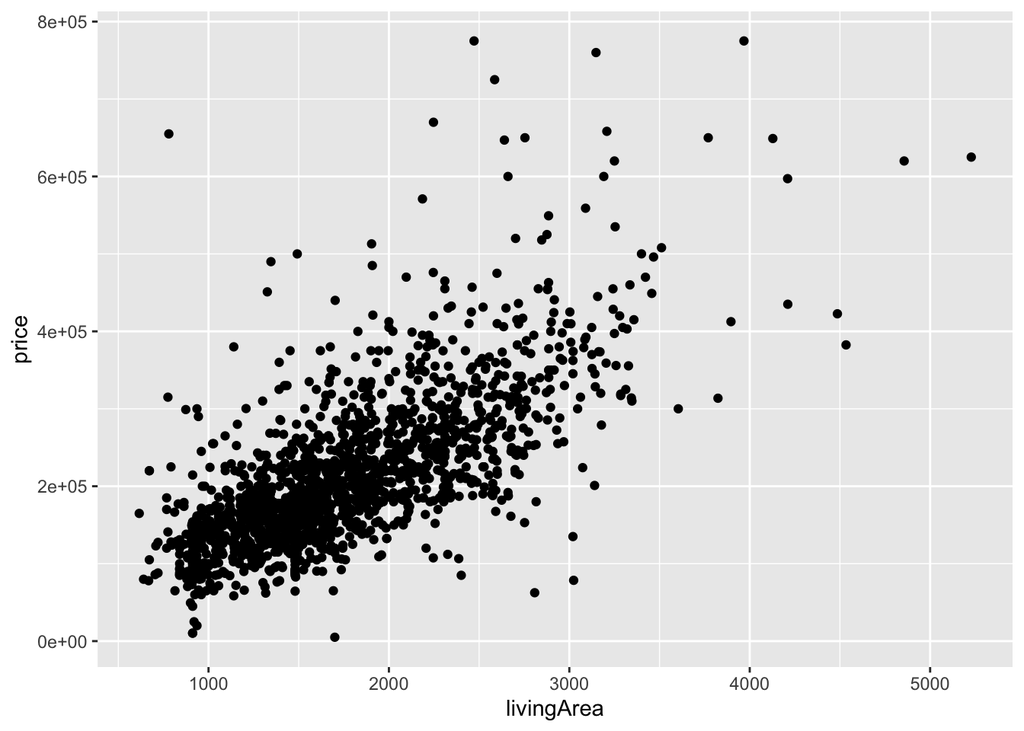

```
## (Intercept)  livingArea     lotSize  fireplaces
##   13656.263     108.239    6007.930    8886.659
```

Scattered point graph was used to see how living area impacts the price of the house and how other variables might affect the overall increase in price.

## Graph 2

Banned items dataset is a collection of items banned in US schools and consits of *schoolName*, *state*, *item*, *type* and *prohibited* column that specifies the gender.

```
## Rows: 15,144
## Columns: 5
## $ schoolName <chr> "RUSK H S", "RUSK H S", "EAST HIGH", "TOMAHAWK HIGH", "TOMA…
## $ state      <chr> "TX", "TX", "UT", "WI", "WI", "WI", "WI", "WI", "OK", "TX",…
## $ item       <chr> "pillows", "stuffed animals", "dangling belts", "wallet cha…
## $ type       <chr> "accessories", "accessories", "accessories", "accessories",…
## $ prohibited <chr> "none", "none", "none", "none", "none", "none", "none", "no…
```

I want to plot a graph to compare two item type based on their frequency in the banned item list. The two items are **pajamas** and **weapons**

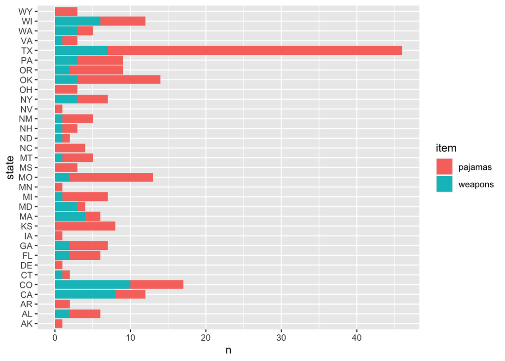

## Graph 3

```
## # A tibble: 19 × 4
##    Name  Sex   Race       Position
##    <chr> <chr> <chr>      <chr>
##  1 RM001 M     White      Professor
##  2 KD002 F     Slavic     Phdstudent
##  3 RB003 F     White      singer
##  4 Y004  M     White      Kate's boyfriend
##  5 PO005 F     White      President
##  6 DO006 M     Black      head of TPDC
##  7 JO007 M     White      President's son
##  8 PI008 M     White      CEO of bash
##  9 JB009 M     Black      TV host
## 10 BE010 F     Australian TV host
## 11 DC011 M     Black      singer
## 12 P012  M     Indian     Journalist
## 13 JM013 F     European   w/o Randal
## 14 AG014 M     Black      Journalist
## 15 GT015 M     <NA>       <NA>
## 16 DC016 F     Asian      Head of NASA
## 17 EM017 M     White      <NA>
## 18 BD018 M     White      Astronaut
## 19 MM019 M     White      <NA>
```

```
## # A tibble: 39 × 4
##    from  to    weight `relation type`
##    <chr> <chr>  <dbl> <chr>
##  1 AG014 RM001      2 situational
##  2 AG014 KD002      1 situational
##  3 BE010 JB009      6 professional
##  4 BE010 RB003      1 situational
##  5 BE010 RM001     10 benefits
##  6 BE010 PI008      1 friends
##  7 BE010 JM013      1 situational
##  8 DC016 RM001      1 professional
##  9 DC016 DO006      1 professional
## 10 DO006 GT015      2 professional
## # … with 29 more rows
```

```
## # A tbl_graph: 19 nodes and 39 edges
## #
## # An undirected simple graph with 1 component
## #
## # Node Data: 19 × 4 (active)
##   Name  Sex   Race   Position
##   <chr> <chr> <chr>  <chr>
## 1 RM001 M     White  Professor
## 2 KD002 F     Slavic Phdstudent
## 3 RB003 F     White  singer
## 4 Y004  M     White  Kate's boyfriend
## 5 PO005 F     White  President
## 6 DO006 M     Black  head of TPDC
## # … with 13 more rows
## #
## # Edge Data: 39 × 4
##    from    to weight `relation type`
##   <int> <int>  <dbl> <chr>
## 1     1    14      2 situational
## 2     2    14      1 situational
## 3     9    10      6 professional
## # … with 36 more rows
```

The network of the characters showing the weight of the interactions they have had in the movie “Don’t look up”. Coord circular graph was used to depict equal importance of every caracter in a socio political issue like climate change which is depicted with a metaphor of comet heading towards Earth. Although evryone has a role to play, some characters who have more networks play a more crucial role.

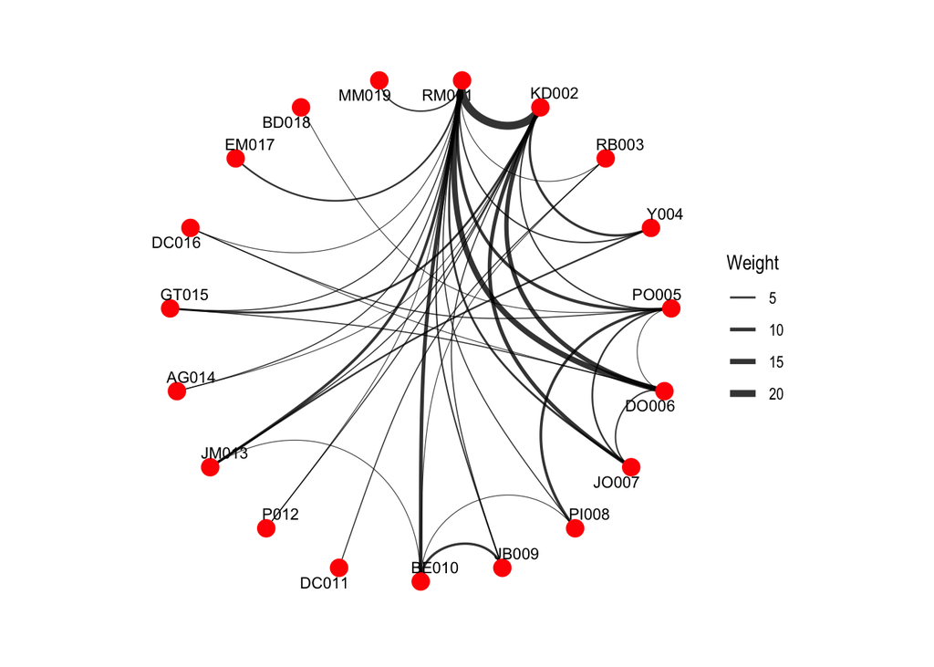

## My Course Reflection

This course was about using data to get insights and revelations on a particular topic.

My major learning from this workshop was to ask imaginative questions before jumping on solving the problems.

As designers we constantly come across the idea of *problem solving*. I feel after this course, I’m aware of the details and insights that data science can reveal. Data as a tool, if used in creative ways can work wonders for a designer.